# Men’s Soccer Data Analysis

# Final Project

## Introduction

The purpose of this project is to take raw data from the UCSB men’s soccer team and find a model that will best predict a player’s total impact.

### What Technology gives us this data?

[output not shown]

Informational video : https://www.youtube.com/watch?v=daPCQhMG7BU&t=32s

### Why might these model be useful?

Many of the predictors in this project are dependent on running speeds and how that carries onto total impact on the body. The main reason this model would be helpful to the teams understanding is to see how players that do not run as much are doing in terms of total impact. If their total impact to their body is low but they are still playing well we can cross-reference this with the game day statistics to evaluate the trade offs between exerted body effort or placement/technique on the field.

## Loading the Data

This data was sent to me from a staff member from the UCSB men’s soccer team because I work with them. Most of it was already cleaned and therefore made it easier to look through. The codebook for this project is in my zipped files and shows the specfics for each predictor.

## Loading Packages

We need to load the necessary packages in here so that we can access functions for our exploratory data analysis and model running later on. Most of our work is centered around the tidyverse and ggplots so we will load these right away.

```r
library(ggplot2)
library(tidyverse)
library(janitor)
library(tidyverse)
library(tidymodels)
library(ggplot2)

library(ISLR)
library(ISLR2)
#install.packages("discrim")
library(discrim)
library(poissonreg)
library(corrr)
library(klaR)
library(corrplot)

library(ggthemes)
tidymodels_prefer()
```

## Data Cleaning

Our data is clean for the most part however there are some unnecessary empty columns and missing data in rows that we have to deal with accordingly.

```r
msocf22 <- read_csv("ucsb_msoc_fall2022.csv") %>%
  clean_names()

msocf22 %>%
  filter(event_result != "No Result")
```

```
## # A tibble: 596 × 41
##    event_date event_de…¹ playe…² event…³ event…⁴ event…⁵ event…⁶ segme…⁷ perfo…⁸
##    <chr>      <chr>      <chr>   <chr>   <chr>   <chr>   <chr>   <chr>     <dbl>
##  1 8/14/2022  San Jose … Athlet… Game    Away    WIN     preSea… *           125
##  2 8/20/2022  Westmont   Athlet… Game    Home    WIN     inSeas… *           117
##  3 8/25/2022  Missouri … Athlet… Game    Away    DRAW    inSeas… *           122
##  4 8/28/2022  Californi… Athlet… Game    Home    WIN     inSeas… *           122
##  5 8/28/2022  Californi… Athlet… Game    Home    WIN     inSeas… 1st Ha…      50
##  6 8/28/2022  Californi… Athlet… Game    Home    WIN     inSeas… 2nd Ha…      56
##  7 9/2/2022   Cornell    Athlet… Game    Home    LOSS    inSeas… *           126
##  8 9/2/2022   Cornell    Athlet… Game    Home    LOSS    inSeas… 1st Ha…      54
##  9 9/2/2022   Cornell    Athlet… Game    Home    LOSS    inSeas… 2nd Ha…      56
## 10 9/4/2022   Loyola Ma… Athlet… Game    Away    WIN     inSeas… *           128
## # … with 586 more rows, 32 more variables: total_distance_m <dbl>,
## #   walk_distance_m <dbl>, jog_distance_m <dbl>, run_distance_m <dbl>,
## #   sprint_distance_m <dbl>, sprint_efforts <dbl>, zone_1_distance_m <dbl>,
## #   zone_2_distance_m <dbl>, zone_3_distance_m <dbl>, zone_4_distance_m <dbl>,
## #   zone_5_distance_m <dbl>, zone_6_distance_m <dbl>, zone_7_distance_m <dbl>,
## #   zone_8_distance_m <dbl>, hard_running_m <dbl>, hard_running_efforts <dbl>,
## #   work_rate_m_min <dbl>, top_speed_m_s <dbl>, intensity <dbl>, …
```

```r
msocf22 %>%
  # filter(event_result != "No Result") %>%
  group_by(event_date)
```

```
## # A tibble: 1,470 × 41
## # Groups:   event_date [46]
##    event_date event_de…¹ playe…² event…³ event…⁴ event…⁵ event…⁶ segme…⁷ perfo…⁸
##    <chr>      <chr>      <chr>   <chr>   <chr>   <chr>   <chr>   <chr>     <dbl>
##  1 8/9/2022   Afternoon… Athlet… Traini… Home    No Res… preSea… *            83
##  2 8/9/2022   Morning P… Athlet… Traini… Home    No Res… preSea… *            97
##  3 8/9/2022   Morning P… Athlet… Traini… Home    No Res… preSea… Warm-Up       9
##  4 8/9/2022   Morning P… Athlet… Traini… Home    No Res… preSea… Accel …      12
##  5 8/9/2022   Morning P… Athlet… Traini… Home    No Res… preSea… Practi…      76
##  6 8/10/2022  Afternoon… Athlet… Traini… Home    No Res… preSea… *           115
##  7 8/10/2022  Morning P… Athlet… Traini… Other   No Res… preSea… *            90
##  8 8/11/2022  Afternoon… Athlet… Traini… Home    No Res… preSea… *            75
##  9 8/11/2022  Morning P… Athlet… Traini… Home    No Res… preSea… *           110
## 10 8/11/2022  Morning P… Athlet… Traini… Home    No Res… preSea… Speed …      27
## # … with 1,460 more rows, 32 more variables: total_distance_m <dbl>,
## #   walk_distance_m <dbl>, jog_distance_m <dbl>, run_distance_m <dbl>,
## #   sprint_distance_m <dbl>, sprint_efforts <dbl>, zone_1_distance_m <dbl>,
## #   zone_2_distance_m <dbl>, zone_3_distance_m <dbl>, zone_4_distance_m <dbl>,
## #   zone_5_distance_m <dbl>, zone_6_distance_m <dbl>, zone_7_distance_m <dbl>,
## #   zone_8_distance_m <dbl>, hard_running_m <dbl>, hard_running_efforts <dbl>,
## #   work_rate_m_min <dbl>, top_speed_m_s <dbl>, intensity <dbl>, …
```

```r
#take out halftime
```

```r
msocf22 <- msocf22%>%
  mutate(total_impact = impact_light + impact_medium+impact_heavy)
msocf22
```

```
## # A tibble: 1,470 × 42
##    event_date event_de…¹ playe…² event…³ event…⁴ event…⁵ event…⁶ segme…⁷ perfo…⁸
##    <chr>      <chr>      <chr>   <chr>   <chr>   <chr>   <chr>   <chr>     <dbl>
##  1 8/9/2022   Afternoon… Athlet… Traini… Home    No Res… preSea… *            83
##  2 8/9/2022   Morning P… Athlet… Traini… Home    No Res… preSea… *            97
##  3 8/9/2022   Morning P… Athlet… Traini… Home    No Res… preSea… Warm-Up       9
##  4 8/9/2022   Morning P… Athlet… Traini… Home    No Res… preSea… Accel …      12
##  5 8/9/2022   Morning P… Athlet… Traini… Home    No Res… preSea… Practi…      76
##  6 8/10/2022  Afternoon… Athlet… Traini… Home    No Res… preSea… *           115
##  7 8/10/2022  Morning P… Athlet… Traini… Other   No Res… preSea… *            90
##  8 8/11/2022  Afternoon… Athlet… Traini… Home    No Res… preSea… *            75
##  9 8/11/2022  Morning P… Athlet… Traini… Home    No Res… preSea… *           110
## 10 8/11/2022  Morning P… Athlet… Traini… Home    No Res… preSea… Speed …      27
## # … with 1,460 more rows, 33 more variables: total_distance_m <dbl>,
## #   walk_distance_m <dbl>, jog_distance_m <dbl>, run_distance_m <dbl>,
## #   sprint_distance_m <dbl>, sprint_efforts <dbl>, zone_1_distance_m <dbl>,
## #   zone_2_distance_m <dbl>, zone_3_distance_m <dbl>, zone_4_distance_m <dbl>,
## #   zone_5_distance_m <dbl>, zone_6_distance_m <dbl>, zone_7_distance_m <dbl>,
## #   zone_8_distance_m <dbl>, hard_running_m <dbl>, hard_running_efforts <dbl>,
## #   work_rate_m_min <dbl>, top_speed_m_s <dbl>, intensity <dbl>, …
```

```r
#msocf22 <- msocf22 %>%
 # mutate(total_impact = factor(total_impact))
#msocf22
```

The outcome variable total_impact did not come in the given data, so we had to mutate a column in for it into the data set. The total_impact is the sum of impact_light, impact_medium and impact_heavy.

```r
msocf22 %>%
  filter(segment_name == "*")
```

```
## # A tibble: 1,040 × 42
##    event_date event_de…¹ playe…² event…³ event…⁴ event…⁵ event…⁶ segme…⁷ perfo…⁸
##    <chr>      <chr>      <chr>   <chr>   <chr>   <chr>   <chr>   <chr>     <dbl>
##  1 8/9/2022   Afternoon… Athlet… Traini… Home    No Res… preSea… *            83
##  2 8/9/2022   Morning P… Athlet… Traini… Home    No Res… preSea… *            97
##  3 8/10/2022  Afternoon… Athlet… Traini… Home    No Res… preSea… *           115
##  4 8/10/2022  Morning P… Athlet… Traini… Other   No Res… preSea… *            90
##  5 8/11/2022  Afternoon… Athlet… Traini… Home    No Res… preSea… *            75
##  6 8/11/2022  Morning P… Athlet… Traini… Home    No Res… preSea… *           110
##  7 8/12/2022  Afternoon… Athlet… Traini… Home    No Res… preSea… *            98
##  8 8/12/2022  Morning P… Athlet… Traini… Home    No Res… preSea… *           124
##  9 8/13/2022  Practice   Athlet… Traini… Home    No Res… preSea… *            95
## 10 8/14/2022  San Jose … Athlet… Game    Away    WIN     preSea… *           125
## # … with 1,030 more rows, 33 more variables: total_distance_m <dbl>,
## #   walk_distance_m <dbl>, jog_distance_m <dbl>, run_distance_m <dbl>,
## #   sprint_distance_m <dbl>, sprint_efforts <dbl>, zone_1_distance_m <dbl>,
## #   zone_2_distance_m <dbl>, zone_3_distance_m <dbl>, zone_4_distance_m <dbl>,
## #   zone_5_distance_m <dbl>, zone_6_distance_m <dbl>, zone_7_distance_m <dbl>,
## #   zone_8_distance_m <dbl>, hard_running_m <dbl>, hard_running_efforts <dbl>,
## #   work_rate_m_min <dbl>, top_speed_m_s <dbl>, intensity <dbl>, …
```

```r
# we want to make sure we don't account for half time just the whole game
msocf22 <- msocf22 %>%
  select(-c(starts_with("hr"))) # these are the empty columns
msocf22 <- msocf22 %>%
  select (-c(impact_light,impact_medium,impact_heavy,event_tags,total_distance_m)) # each impact factors into total impact so the same way we had to factor age of the abalone data we must do the same here, event_tags was just an unnecessary row we had
#msocf22 <- msocf22 %>%
  #select(-c(total_distance_m))
#msocf22
```

```r
msocf22 #one last check up on the data
```

```
## # A tibble: 1,470 × 29
##    event_date event_de…¹ playe…² event…³ event…⁴ event…⁵ segme…⁶ perfo…⁷ walk_…⁸
##    <chr>      <chr>      <chr>   <chr>   <chr>   <chr>   <chr>     <dbl>   <dbl>
##  1 8/9/2022   Afternoon… Athlet… Traini… Home    No Res… *            83    840.
##  2 8/9/2022   Morning P… Athlet… Traini… Home    No Res… *            97   1176.
##  3 8/9/2022   Morning P… Athlet… Traini… Home    No Res… Warm-Up       9    125.
##  4 8/9/2022   Morning P… Athlet… Traini… Home    No Res… Accel …      12    189.
##  5 8/9/2022   Morning P… Athlet… Traini… Home    No Res… Practi…      76    887.
##  6 8/10/2022  Afternoon… Athlet… Traini… Home    No Res… *           115   1377.
##  7 8/10/2022  Morning P… Athlet… Traini… Other   No Res… *            90   1033.
##  8 8/11/2022  Afternoon… Athlet… Traini… Home    No Res… *            75    860.
##  9 8/11/2022  Morning P… Athlet… Traini… Home    No Res… *           110   1243.
## 10 8/11/2022  Morning P… Athlet… Traini… Home    No Res… Speed …      27    343.
## # … with 1,460 more rows, 20 more variables: jog_distance_m <dbl>,
## #   run_distance_m <dbl>, sprint_distance_m <dbl>, sprint_efforts <dbl>,
## #   zone_1_distance_m <dbl>, zone_2_distance_m <dbl>, zone_3_distance_m <dbl>,
## #   zone_4_distance_m <dbl>, zone_5_distance_m <dbl>, zone_6_distance_m <dbl>,
## #   zone_7_distance_m <dbl>, zone_8_distance_m <dbl>, hard_running_m <dbl>,
## #   hard_running_efforts <dbl>, work_rate_m_min <dbl>, top_speed_m_s <dbl>,
## #   intensity <dbl>, load_2d <dbl>, load_3d <dbl>, total_impact <dbl>, and …
```

### Data Splitting

```r
set.seed(5555) #so that the same random variables are used when we re run the code

msocf22_split <- initial_split(msocf22, prop = 0.70,
                               strata = total_impact) #stratifying on the outcome variable
msocf22_train <- training(msocf22_split)
msocf22_test <- testing(msocf22_split)

dim(msocf22_train)/nrow(msocf22) #checking if the proportions of the split data are correct
```

```
## [1] 0.69863946 0.01972789
```

```r
dim(msocf22_test)/nrow(msocf22)
```

```
## [1] 0.30136054 0.01972789
```

We want to split our data into a testing and training data set stratifying on the outcome.This is because our outcomes distribution was heavily skewed. We stratify on outcome because we would like to maintain the distribution of the outcome for all the resampling. In the first line of code in this block we set.seed() so that the same random variables are used every time we rerun the code.

## Exploratory Data Analysis

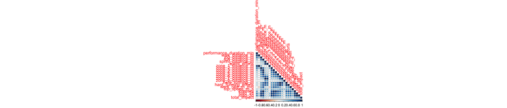

```r
library(corrplot)

msocf22_train %>%
  select_if(is.numeric) %>%
  cor() %>%
  corrplot(type = "lower")
```

Here we construct a correlation plot with all the possible relevant predictors so far to see if anything stands out and if we should be cautious of that. The first thing that should catch your eyes is that “jog_distance_m” and “zone_2_distance_m” have a perfect positive correlation and so does “walk_distance_m” and “zone_distance_1”. This can be explained by the fact that these zone speeds are the exact same speeds needed for a player to fall into either the jog, walk, run, or sprint categories. This is helpful to us because we can determine that our recipe does not need each zone distance because that speed is already accounted for within “jog_distance_m”, “run_distance_m”, “sprint_distance_m”, and “walk_distance_m”. However, this also opens the possibility to creating interactions between the predictors to again create a more condense model and not waste time looking at a predictor that is already within another one of our predictors. Lastly one should note that we only have positive correlations because every predictor we are looking at has to do with running, speed and efforts put in. Generally the more effort you put in the faster you go explaining most of the positive correlations we are witnessing here. There is no pair of predictors here where doing worse for one will be better for the other. To combat the perfect correlation values we talked about before we learned in lecture that we can use the principal component analysis (a form of dimension reduction) and take the relationships we deem as “interesting” and condense them into less predictors. This way we save all the data and simply the recipe we will create later.

```
## geom_path: Each group consists of only one observation. Do you need to adjust
## the group aesthetic?
```

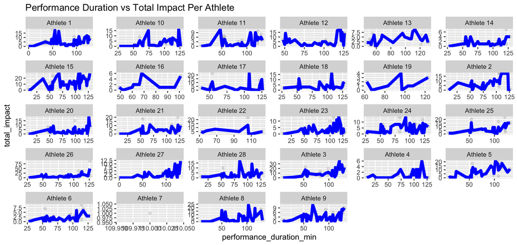

```r
msocf22_train %>%
  ggplot(aes(performance_duration_min, total_impact))+ #wish to see the relationship between performance minutes and outcome based on athlete
  geom_point(alpha=0.1) +
  stat_summary(fun=mean, colour="blue",geom = "line",size = 2)+
  facet_wrap(~player_name,scales="free")+ # i'd like a plot per player so we put "~" player to get all the players
  labs(
    title = "Performance Duration vs Total Impact Per Athlete"
  )
```

```r
msocf22 <-msocf22[-c(358),]
msocf22
```

```
## # A tibble: 1,469 × 29
##    event_date event_de…¹ playe…² event…³ event…⁴ event…⁵ segme…⁶ perfo…⁷ walk_…⁸
##    <chr>      <chr>      <chr>   <chr>   <chr>   <chr>   <chr>     <dbl>   <dbl>
##  1 8/9/2022   Afternoon… Athlet… Traini… Home    No Res… *            83    840.
##  2 8/9/2022   Morning P… Athlet… Traini… Home    No Res… *            97   1176.
##  3 8/9/2022   Morning P… Athlet… Traini… Home    No Res… Warm-Up       9    125.
##  4 8/9/2022   Morning P… Athlet… Traini… Home    No Res… Accel …      12    189.
##  5 8/9/2022   Morning P… Athlet… Traini… Home    No Res… Practi…      76    887.
##  6 8/10/2022  Afternoon… Athlet… Traini… Home    No Res… *           115   1377.
##  7 8/10/2022  Morning P… Athlet… Traini… Other   No Res… *            90   1033.
##  8 8/11/2022  Afternoon… Athlet… Traini… Home    No Res… *            75    860.
##  9 8/11/2022  Morning P… Athlet… Traini… Home    No Res… *           110   1243.
## 10 8/11/2022  Morning P… Athlet… Traini… Home    No Res… Speed …      27    343.
## # … with 1,459 more rows, 20 more variables: jog_distance_m <dbl>,
## #   run_distance_m <dbl>, sprint_distance_m <dbl>, sprint_efforts <dbl>,
## #   zone_1_distance_m <dbl>, zone_2_distance_m <dbl>, zone_3_distance_m <dbl>,
## #   zone_4_distance_m <dbl>, zone_5_distance_m <dbl>, zone_6_distance_m <dbl>,
## #   zone_7_distance_m <dbl>, zone_8_distance_m <dbl>, hard_running_m <dbl>,
## #   hard_running_efforts <dbl>, work_rate_m_min <dbl>, top_speed_m_s <dbl>,
## #   intensity <dbl>, load_2d <dbl>, load_3d <dbl>, total_impact <dbl>, and …
```

After the last plot we saw that Athlete 7 does not have many data points indicating they left the team or were injured, so their data is not necessarily useful to us.

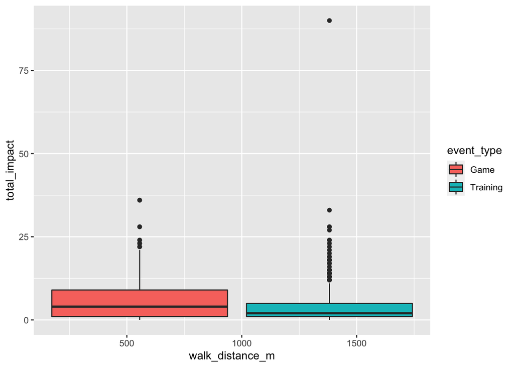

```r
ggplot(msocf22_train, aes(x=walk_distance_m, y=total_impact, fill=event_type)) +
  geom_boxplot() # here we construct a normal boxplot with ggplot
```

The relationship between this bar plot was mainly to see if players are using training as more of a time to heal and relax their bodies keeping it low impact or not. The plots have similar mean values because a training session is much longer than a game meaning even if they are not doing as much they have time to walk around as much as they would in a game. However one can see that the walk distance for games is much lower than ones from training because in training some players who are subbed off can walk around much more than they would in a game. The outliers we see on the game box plot could be the defenders on our team because they do have time to walk around more when we are on the attack side and they still have high impact values because when they do play they are exerting a lot of physical energy.

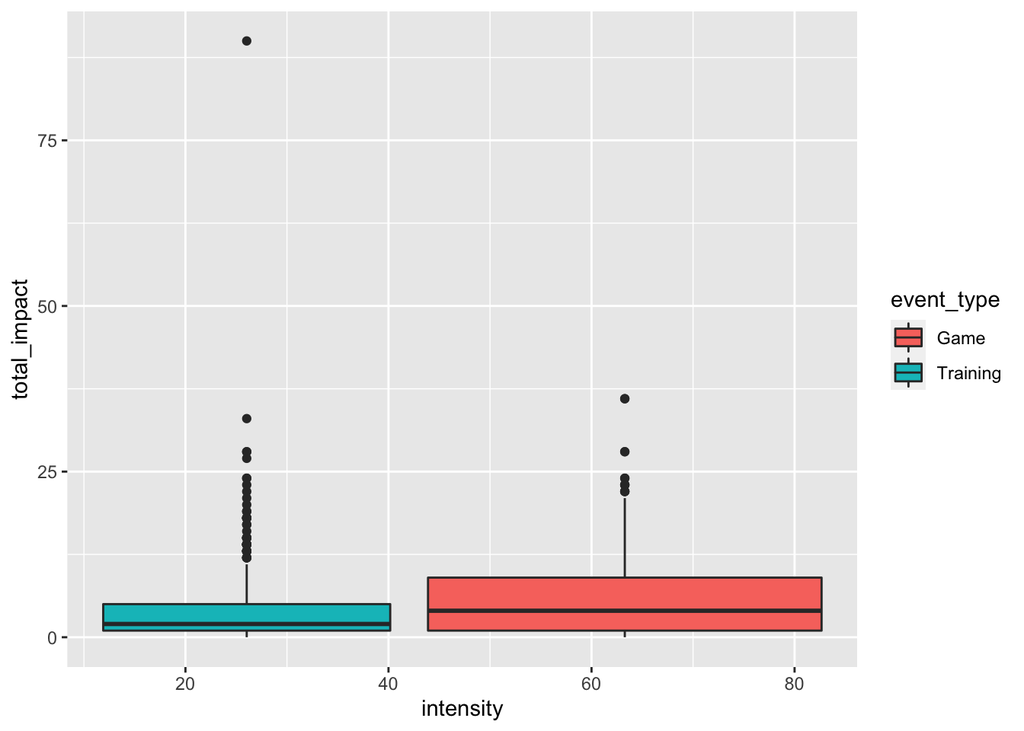

```r
ggplot(msocf22_train, aes(x=intensity, y=total_impact, fill=event_type)) +
  geom_boxplot() # here we construct a normal boxplot with ggplot
```

This plot I created after running the random forest model because through one of our visuals it showed us that intensity was the most relevant predictor. It is smart to check out the relationship between them to see if anything stands out. It seems that intensity is much higher on game days which makes a lot of sense because most players are running the whole 90 minutes. The larger range on the game box plot could also be explained by how much playing time a player is getting and how much intensity they are putting in affecting the total impact and the distribution we see. The training box plot also makes sense because there shouldn’t be a huge range when everyone is exerting the same amount of effort for practice when the coach is allowed to stop them and talk to them etc. The outliers can be explained by how sometimes players who played the entire game the day before are able to sit out for training to relax their bodies meaning other players are exerting much more effort then them making them have a higher total impact throughout training.

```r
msocf22_train$total_impact %>%
  table()
```

```
## .
##   0   1   2   3   4   5   6   7   8   9  10  11  12  13  14  15  16  17  18  19
## 180 152 119 106  85  67  42  47  39  36  21  17  11  15  14  12   6  10  12   6
##  20  21  22  23  24  27  28  33  36  90
##   7   2   4   4   4   1   4   1   2   1
```

```r
#check out the distribution
```

Before we look at the distribution of the outcome we would like to see each number to get an idea of what to expect.

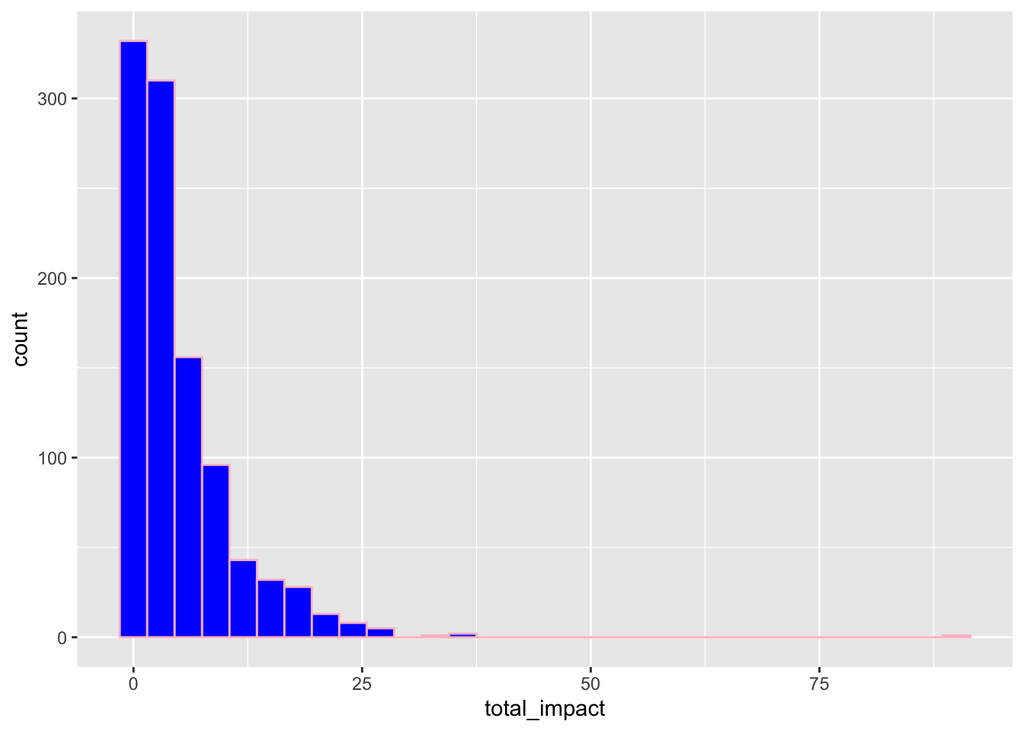

```r
#histogram of our outcome variable
outcome_hist <- ggplot(msocf22_train,aes(x=total_impact)) +
  geom_histogram(color="pink",fill = "blue",binwidth = 3) #making bins more legible
outcome_hist
```

This histogram of our outcome is uni-model and right-sckew. The distribution makes sense because total impact is dependent on how much players are on the field and how hard they choose to go. Our tracker’s metrics make it normal to have a lower total_impact because anything too high would mean the player is going out of their comfort zone/ are not accumulated to the workout probably leaving them sore the next day. This is not what we want in order to prevent injury, that is why it is important for us to track things like this to make sure players have a steady and healthy increase of action during games and practices. The last thing we should note is that there is a positive skew on our distribution here.

## Model Building

```r
msocf22_recipe <- recipe(total_impact ~ performance_duration_min + walk_distance_m + jog_distance_m+
                           run_distance_m + sprint_distance_m + sprint_efforts + hard_running_m +  work_rate_m_min + top_speed_m_s + intensity + zone_1_distance_m + zone_2_distance_m + zone_3_distance_m + zone_4_distance_m + zone_5_distance_m + zone_6_distance_m + zone_7_distance_m + zone_8_distance_m, data = msocf22_train) %>%
  step_normalize(all_predictors())%>% #normalize the model, same as step center and step scale
  step_dummy(all_nominal_predictors()) %>%
 step_pca(walk_distance_m,zone_1_distance_m,jog_distance_m,zone_2_distance_m,run_distance_m,zone_3_distance_m,zone_4_distance_m,sprint_distance_m,zone_7_distance_m,num_comp = 4) #due to the high correlations we use pca with 4 components to simply the recipe but keep all data in tact
msocf22_recipe %>%
  prep() %>%
  juice() # gives use a preview tibble
```

```
## # A tibble: 1,027 × 14
##    performance…¹ sprin…² hard_…³ work_…⁴ top_s…⁵ inten…⁶ zone_…⁷ zone_…⁸ zone_…⁹
##            <dbl>   <dbl>   <dbl>   <dbl>   <dbl>   <dbl>   <dbl>   <dbl>   <dbl>
##  1        -2.52   -0.558  -0.987 -0.322  -2.50   -1.52   -1.04   -0.964   -0.370
##  2        -0.221   0.271   0.506  0.0995  0.590   0.184   0.214   0.387   -0.154
##  3        -0.120  -0.558  -0.720 -0.658   0.0145 -0.556  -0.714  -0.671   -0.370
##  4         0.590  -0.558  -0.515 -0.608  -0.177  -0.488  -0.629  -0.413   -0.370
##  5        -1.13    1.93    0.160  0.798   0.329  -0.110  -0.0900  0.0497  -0.370
##  6         0.353   1.93    0.556 -0.394   0.843  -0.266  -0.0593  0.747    0.297
##  7        -2.82   -0.558  -0.987 -2.67   -5.65   -1.62   -1.06   -0.964   -0.370
##  8        -2.52   -0.558  -0.980 -0.236  -1.80   -1.52   -1.04   -0.964   -0.370
##  9         1.33    1.10    0.340 -0.545   0.306   0.0599 -0.0938  0.227   -0.370
## 10        -0.390  -0.558  -0.514 -0.498  -0.369  -0.731  -0.479  -0.403   -0.370
## # … with 1,017 more rows, 5 more variables: total_impact <dbl>, PC1 <dbl>,
## #   PC2 <dbl>, PC3 <dbl>, PC4 <dbl>, and abbreviated variable names
## #   ¹performance_duration_min, ²sprint_efforts, ³hard_running_m,
## #   ⁴work_rate_m_min, ⁵top_speed_m_s, ⁶intensity, ⁷zone_5_distance_m,
## #   ⁸zone_6_distance_m, ⁹zone_8_distance_m
```

```r
#leaving loads and zone distances out, they are speed of each zone and load 2d and 3d are irrelevant to our data
```

Our recipe is a very important part of building our models. Now that we saw what data to get rid of and alter in our data cleaning and eda and wer proceed by creating the backbone of our models. Initially in our recipe we choose to get rid of zone distances for all 8 zones because they were just a reiteration of the speeds contained in either walking, running, sprinting, or jogging distances. However, in order to yield better results and not get rid of predictors we problem solved by using the PCA method. In this method we were able to combine,walk_distance_m and zone_1_distance_m,jog_distance_m and zone_2_distance_m, run_distance_m and zone_3_distance_m as well as zone_4_distance_m, and finally sprint_distance_m and zone_7_distance_m. To combat all the pairs and the one trios we used num_comp as four because we went from 9 predictors to basically four. We choose to have 4 componenets instead of one because we would like to see how each type of movement: running, jogging, walking, and sprinting affect the outcome. This is because our whole project is based on different types of running and speeds and how they impact the body. Lastly because we know the data set and we know predictors like the load zones are irrelevant to the outcome factor we may simply remove them.

```r
#k-fold cross validation
msocf22_fold <- vfold_cv(msocf22_train,v=10) # you can use 5-10 folds, but because I do not have a large amount of data I choose to re sample with more folds because the running time would not be drastic
msocf22_fold
```

```
## #  10-fold cross-validation
## # A tibble: 10 × 2
##    splits            id
##    <list>            <chr>
##  1 <split [924/103]> Fold01
##  2 <split [924/103]> Fold02
##  3 <split [924/103]> Fold03
##  4 <split [924/103]> Fold04
##  5 <split [924/103]> Fold05
##  6 <split [924/103]> Fold06
##  7 <split [924/103]> Fold07
##  8 <split [925/102]> Fold08
##  9 <split [925/102]> Fold09
## 10 <split [925/102]> Fold10
```

We learned that for most machine learning problems in this course it is safe to use 5 or 10 folds when performing cross fold validation. With k fold cross validation we avoid using the whole data set instead we have k-1 folds that we fit with our training data to learn the data and then finally we can apply the learned models to our 1 fold of testing data.

## General Understanding

We choose to test many models on this data including a linear regression, polynomial regression, ridge, lasso, k nearest neighbors, random forest, and boosted trees. For the most part the understanding for models here is to note we have regression model because even though our outcome is categorical we consider there to be too high a range for our numerical values that have categorical meanings. We will basically put our values into bins that we can deal with after the fact. To start making our models we always want to use the set_engine() function with the specific model we are using and then from there we create a workflow that will take in our initial recipe and our new model and put them together so that we can then fit the model. For most of our models you will notice we have the auto_plot() function to look at a visual and then we will use the select_best() function to get the best metric for all the models at the end. Another thing to note is that we will fit all of our mdoels on the training data so that the models can learn and then eventually once we have the best model we will fit it to out testing data. Lastly we will tune all these models so that we can incorporate our folds we created earlier and yield the best results by learning on the training data.

```r
#linear regression model

lm_model<- linear_reg() %>%
  set_engine("lm")
lm_wkflow <- workflow() %>%
  add_model(lm_model) %>%
  add_recipe(msocf22_recipe) #fitting our recipe with the training data to our model

lm_fit <- fit(lm_wkflow,msocf22_train)# fitting our model to the training data

msocf22_train_res <- predict(lm_fit, new_data = msocf22_train %>% select(-total_impact))
msocf22_train_res %>%
  head()
```

```
## # A tibble: 6 × 1
##   .pred
##   <dbl>
## 1 0.279
## 2 5.68
## 3 3.19
## 4 3.70
## 5 4.60
## 6 3.99
```

```r
msocf22_train_res <- bind_cols(msocf22_train_res, new_data = msocf22_train %>% select(total_impact))
msocf22_train_res %>%
  head()
```

```
## # A tibble: 6 × 2
##   .pred total_impact
##   <dbl>        <dbl>
## 1 0.279            0
## 2 5.68             1
## 3 3.19             0
## 4 3.70             1
## 5 4.60             1
## 6 3.99             0
```

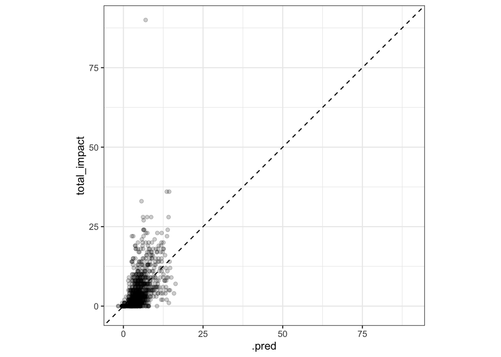

```r
# lines 200 - 206 are us getting a prediction versus the actual value from our model
msocf22_train_res %>%
  ggplot(aes(x=.pred,y=total_impact)) +
  geom_point(alpha = 0.2)+
  geom_abline(lty=2)+
  theme_bw()+
  coord_obs_pred() # creating a visual residual graph
```

```r
lm_train_rmse <- sqrt(mean((msocf22_train_res$total_impact - msocf22_train_res$.pred)^2))
lm_train_rmse
```

```
## [1] 5.371054
```

```r
# creating a variable for the training rmse to eventually pick the best one when put in a tibble
```

The linear model is one of our most simple models that we learned in this class. The differences one can notice in this code is how we make a residual plot to see how our model did instead of using an auto_plot() visualization. The only other difference is that we got the root mean squared error manually instead of using the select_best function. Here we are taking the recipe we built with our training data and fitting that for a linear model. From there we calculated both the predicted outcome values and the actual outcome values so that we could create a visual with the residual plot. From what we see this model probably did not do the best because we want the residual plot to form a straight line and we have most of our values in the bottom left corner.

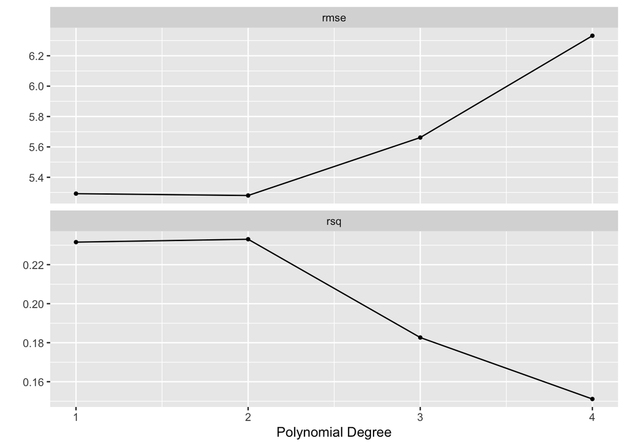

```r
#polynomial regression
poly_rec <-  msocf22_recipe %>%
  step_poly(all_predictors(),degree=tune()) # we will choose to tune in most model to yield the best results, this is also a function for the polynomial model


lm_spec <- linear_reg()%>%
  set_mode("regression")%>%
  set_engine("lm")

poly_wkflow <- workflow() %>%
  add_model(lm_spec)  %>%
  add_recipe(poly_rec) #taking the linear model and transforming for our polynomial regression

degree_grid_poly <- grid_regular(degree(range=c(1,4)),levels=4) # we use the number four because we'd like a degree that is higher than 1 but not so large


tune_res_poly <- tune_grid(
  poly_wkflow,
  resamples = msocf22_fold,
  grid = degree_grid_poly
)# like every other model this is the far where we tune and find the best degree for our model with the polynomial regression model
autoplot(tune_res_poly)
```

```r
#select best

best_poly <- select_best(tune_res_poly, metric="rmse")
best_poly
```

```
## # A tibble: 1 × 2
##   degree .config
##    <dbl> <chr>
## 1      2 Preprocessor2_Model1
```

```r
poly_final <- finalize_workflow(poly_wkflow,best_poly)

poly_final_fit <- fit(poly_final, data = msocf22_train)

poly_train_rmse <- augment(poly_final_fit, new_data = msocf22_train) %>%
  rmse(truth = total_impact, estimate = .pred)
poly_train_rmse
```

```
## # A tibble: 1 × 3
##   .metric .estimator .estimate
##   <chr>   <chr>          <dbl>
## 1 rmse    standard        5.31
```

```r
augment(poly_final_fit, new_data = msocf22_test) %>%
  rmse(truth = total_impact, estimate = .pred)
```

```
## # A tibble: 1 × 3
##   .metric .estimator .estimate
##   <chr>   <chr>          <dbl>
## 1 rmse    standard        10.1
```

Since this is the first time we are running a model more complex and similar to the others there are some new things in the code. First we now are tuning this model so that we can get an idea of what is the ideal polynomial degree for our polynomial regression model. In this step we fit a polynomial regression with our degree range going from 1-4. After the model was fit we used the function auto_plot() on our tuned model to see how it would do in terms of the polynomial degree in comparison to both rmse and rsq.This is the part where we can identify the best degree. From both of the visuals it is easy to see that the model has a higher rsq and lower rmse at lower polynomial degrees. This is ideal because a high rsq shows that most of the variability caused in the outcome is explained by our predictors and a low rmse means we have a low error rate. Secondly we then move on by selecting the best rmse value because that is what we will be using to compare all the models later. We finalize a new workflow with this best value so that we can fit the model with it and then extract the best rmse and even fit the testing data to see how it does. In this case we were interested so we can see that that training versus testing rmse almost doubles which is not ideal.

```r
#ridge regression model

ridge_spec <-
  linear_reg(penalty = tune(), mixture = 0)%>% # the mixture of 0 specifies a ridge regression
  set_mode("regression")%>%
  set_engine("glmnet") #engine specific to the ridge model
ridge_workflow <- workflow() %>%
  add_recipe(msocf22_recipe)%>%
  add_model(ridge_spec)
penalty_grid <- grid_regular(penalty(range=c(-5,5)),levels=50) #these are the values we used in our previous examples of this problem
penalty_grid
```

```
## # A tibble: 50 × 1
##      penalty
##        <dbl>
##  1 0.00001
##  2 0.0000160
##  3 0.0000256
##  4 0.0000409
##  5 0.0000655
##  6 0.000105
##  7 0.000168
##  8 0.000268
##  9 0.000429
## 10 0.000687
## # … with 40 more rows
```

```r
tune_res <- tune_grid(
  ridge_workflow,
  resamples = msocf22_fold,
  grid = penalty_grid
)
tune_res #we want to tune our model and then include our cross validation folds so that we can resample
```

```
## # Tuning results
## # 10-fold cross-validation
## # A tibble: 10 × 4
##    splits            id     .metrics           .notes
##    <list>            <chr>  <list>             <list>
##  1 <split [924/103]> Fold01 <tibble [100 × 5]> <tibble [1 × 3]>
##  2 <split [924/103]> Fold02 <tibble [100 × 5]> <tibble [1 × 3]>
##  3 <split [924/103]> Fold03 <tibble [100 × 5]> <tibble [1 × 3]>
##  4 <split [924/103]> Fold04 <tibble [100 × 5]> <tibble [1 × 3]>
##  5 <split [924/103]> Fold05 <tibble [100 × 5]> <tibble [1 × 3]>
##  6 <split [924/103]> Fold06 <tibble [100 × 5]> <tibble [1 × 3]>
##  7 <split [924/103]> Fold07 <tibble [100 × 5]> <tibble [1 × 3]>
##  8 <split [925/102]> Fold08 <tibble [100 × 5]> <tibble [1 × 3]>
##  9 <split [925/102]> Fold09 <tibble [100 × 5]> <tibble [1 × 3]>
## 10 <split [925/102]> Fold10 <tibble [100 × 5]> <tibble [1 × 3]>
##
## There were issues with some computations:
##
##   - Warning(s) x10: A correlation computation is required, but `estimate` is constant...
##
## Run `show_notes(.Last.tune.result)` for more information.
```

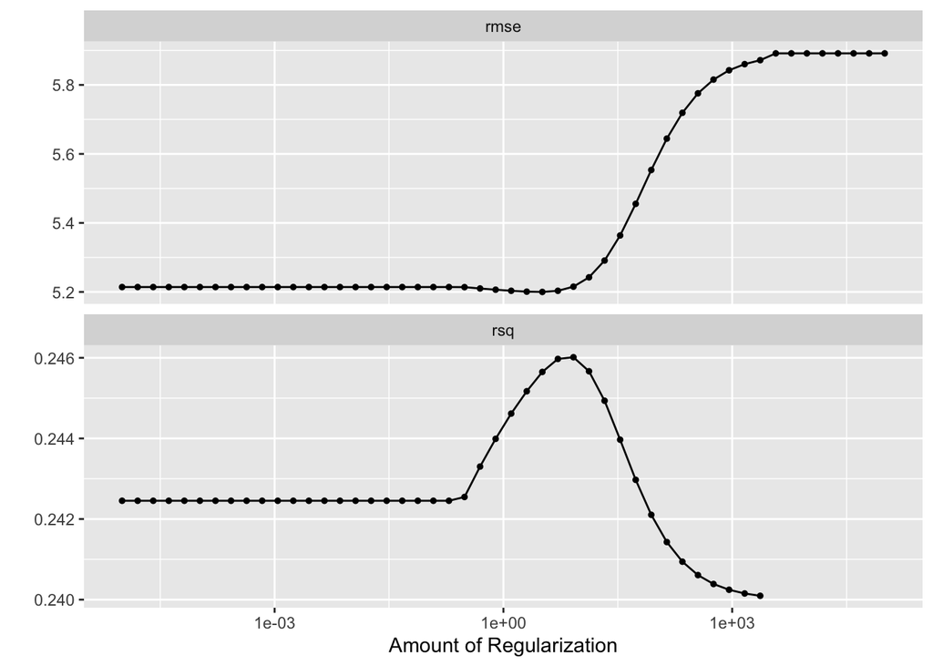

```r
autoplot(tune_res)
```

```r
#plot lambda versus rsq and rmse
#working on finding the best penalty for our data
collect_metrics(tune_res)
```

```
## # A tibble: 100 × 7
##      penalty .metric .estimator  mean     n std_err .config
##        <dbl> <chr>   <chr>      <dbl> <int>   <dbl> <chr>
##  1 0.00001   rmse    standard   5.21     10  0.526  Preprocessor1_Model01
##  2 0.00001   rsq     standard   0.242    10  0.0238 Preprocessor1_Model01
##  3 0.0000160 rmse    standard   5.21     10  0.526  Preprocessor1_Model02
##  4 0.0000160 rsq     standard   0.242    10  0.0238 Preprocessor1_Model02
##  5 0.0000256 rmse    standard   5.21     10  0.526  Preprocessor1_Model03
##  6 0.0000256 rsq     standard   0.242    10  0.0238 Preprocessor1_Model03
##  7 0.0000409 rmse    standard   5.21     10  0.526  Preprocessor1_Model04
##  8 0.0000409 rsq     standard   0.242    10  0.0238 Preprocessor1_Model04
##  9 0.0000655 rmse    standard   5.21     10  0.526  Preprocessor1_Model05
## 10 0.0000655 rsq     standard   0.242    10  0.0238 Preprocessor1_Model05
## # … with 90 more rows
```

```r
best_penalty_rsq <- select_best(tune_res, metric = "rsq")
best_penalty_rsq
```

```
## # A tibble: 1 × 2
##   penalty .config
##     <dbl> <chr>
## 1    8.29 Preprocessor1_Model30
```

```r
best_penalty_rmse <- select_best(tune_res,metric="rmse")
best_penalty_rmse
```

```
## # A tibble: 1 × 2
##   penalty .config
##     <dbl> <chr>
## 1    3.24 Preprocessor1_Model28
```

```r
ridge_final <- finalize_workflow(ridge_workflow,best_penalty_rsq)

ridge_final_fit <- fit(ridge_final, data = msocf22_train)
ridge_train_rmse <- augment(ridge_final_fit, new_data = msocf22_train) %>%
  rmse(truth = total_impact, estimate = .pred)
ridge_train_rmse
```

```
## # A tibble: 1 × 3
##   .metric .estimator .estimate
##   <chr>   <chr>          <dbl>
## 1 rmse    standard        5.43
```

```r
#here I am seeing how the model does with the testing data just to see how it did
augment(ridge_final_fit, new_data = msocf22_test) %>%
  rmse(truth = total_impact, estimate = .pred)
```

```
## # A tibble: 1 × 3
##   .metric .estimator .estimate
##   <chr>   <chr>          <dbl>
## 1 rmse    standard        10.1
```

The same work goes into our code here as before, we tune our model and then proceed to find the best values from the training data. The ridge model is unlike the lasso model in which it only shrinks predictors instead of making their value basically zero. The lasso model will shrink and eliminate preidctors to a zero value faster if they are irrelevant. As we can see in the visual the rmse becomes larger as lambda becomes larger which is not what we want, we prefer a smaller root mean square error. However, the r^2 value which we talked about earlier gets larger as lambda gets around 1e+00 and then gets much lower when it nears 1e+03. This means there is an ideal value of lambda where around 1e+00 where both r^2 and root mean square error hold ideal values. Another thing to note is that we looked at the testng data here again and the training to testing rmse is still almost doubled. Again, this is not ideal we would want the values to be as close as possible to each other because our training data is used to learned the behavior our data and our testing data is saved to see if the models are valid. A problem that usually creates a difference between the training and testing data results is over fitting. This could also be our problem.

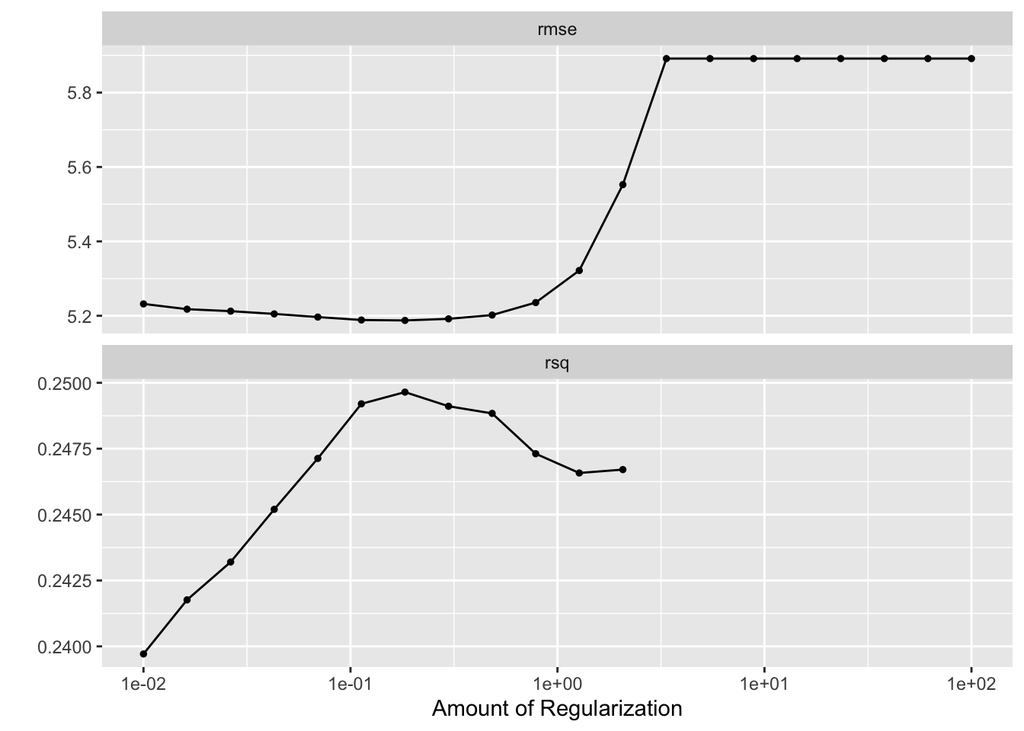

```r
#lasso regression model
lasso_spec <-
  linear_reg(penalty = tune(),mixture = 1)%>%  # the mixture of 1 specifies a lasso regression
  set_mode("regression")%>%
  set_engine("glmnet")

lasso_workflow <- workflow() %>%
  add_recipe(msocf22_recipe)%>%
  add_model(lasso_spec)

penalty_grid <- grid_regular(penalty(range = c(-2,2)),levels=20) # these were also the values we learned to use on previous problems

tune_res <- tune_grid(
  lasso_workflow,
  resamples = msocf22_fold,
  grid = penalty_grid
)
autoplot(tune_res)
```

```r
best_penalty <- select_best(tune_res, metric="rmse")

lasso_final <- finalize_workflow(lasso_workflow,best_penalty)

lasso_final_fit <- fit(lasso_final, data = msocf22_train)
lasso_train_rmse <- augment(lasso_final_fit, new_data = msocf22_train) %>%
  rmse(truth = total_impact, estimate = .pred)
lasso_train_rmse
```

```
## # A tibble: 1 × 3
##   .metric .estimator .estimate
##   <chr>   <chr>          <dbl>
## 1 rmse    standard        5.38
```

```r
augment(lasso_final_fit, new_data = msocf22_test) %>%
  rmse(truth = total_impact, estimate = .pred)
```

```
## # A tibble: 1 × 3
##   .metric .estimator .estimate
##   <chr>   <chr>          <dbl>
## 1 rmse    standard        10.1
```

Again we have a similar thought process on the code as we did starting with the polynomial regression. The difference between the ridge and lasso model is that the lasso model allows predictors to be shrunk down to the value 0 and the predictors that hit 0 first are the most irrelevant to us. From our graphs here we see that similar to the ridge model our rmse value is most ideal because we approach the lambda value of 1+e00 ( again we would like a look root mean square error).Our r^2 value which explained variability in outcome seems to do better as lambda increases but also starts to decrease around 1e+00 lambda.

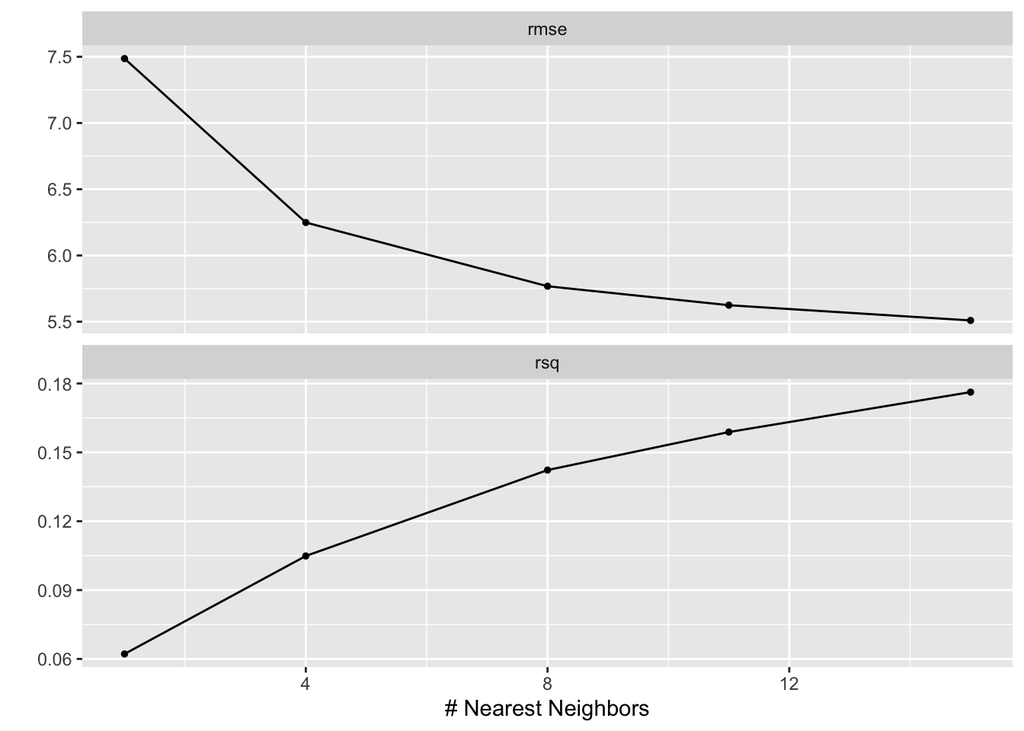

```r
#k-nearest neighbor
#install.packages("kknn")
knn_model <-
  nearest_neighbor(
    neighbors = tune(),
    mode = "regression") %>%
  set_engine("kknn")# engine specific to this model

knn_workflow <- workflow() %>%
  add_model(knn_model)%>%
  add_recipe(msocf22_recipe)

knn_params <- parameters(knn_model)

knn_grid <- grid_regular(knn_params, levels = 5)

knn_tune <- knn_workflow %>%
  tune_grid(
    resamples = msocf22_fold,
    grid = knn_grid)#tuning this model as well


autoplot(knn_tune)
```

In the k-nearest model we are tuning to find the idea value of k so we know how many groups we would like to visually group our data in. This way with new data points we would have grouping boundaries and we would know what group new data points would belong to. From the looks of it both r^2 and rmse values are the most ideal with the highest value of k past 12.

```r
best_knn <- select_best(knn_tune, metric = "rmse")


knn_final <- finalize_workflow(knn_workflow,best_knn)

knn_final_fit <- fit(knn_final, data = msocf22_train)

knn_train_rmse <- augment(knn_final_fit, new_data = msocf22_train) %>%
  rmse(truth = total_impact, estimate = .pred)
knn_train_rmse
```

```
## # A tibble: 1 × 3
##   .metric .estimator .estimate
##   <chr>   <chr>          <dbl>
## 1 rmse    standard        4.49
```

```r
augment(knn_final_fit, new_data = msocf22_test) %>%
  rmse(truth = total_impact, estimate = .pred)
```

```
## # A tibble: 1 × 3
##   .metric .estimator .estimate
##   <chr>   <chr>          <dbl>
## 1 rmse    standard        10.3
```

Similar to all the other models we are using the select_best() function here in order to attain the best value in rmse for this model so that we can later compare with others. I did test this model to the testing data out of curiosity and similar to other models I’ve done this too the rmse on the training data set doubles when we use the testing dataset. The rmse values are relative to our outcomes’ range which goes past 75 on the histogram above, but really only has data points to around 25. This means our model outcomes are now the most ideal but also not the worst in comparison to our outcomes’ range.

```r
#random forest
#install.packages("rpart.plot")
#install.packages("vip")
#install.packages("janitor")
#install.packages("randomForest")
#install.packages("xgboost")
library(rpart.plot)
library(vip)
library(janitor)
library(randomForest)
library(xgboost)

rf_spec <- rand_forest(mtry=tune(),trees=tune(),min_n=tune())%>%
  set_engine("ranger",importance="impurity")%>%
  set_mode("regression")
rf_wk <- workflow()%>%
  add_recipe(msocf22_recipe)%>%
  add_model(rf_spec)

param_grid_rf <- grid_regular(mtry(range=c(1,12)),trees(range=c(500,1000)),min_n(range = c(1,10)),levels = 12)
```

Now we are moving on to tree models which are known to work well in general. We split up most of the code here with the random forest model because it will have a long running time and we want to save the later parts in a file where we can easily rerun them. In this block we will simply fit our model with its engine and create the workflow that will take in our recipe and finally create the grid that evenly spaces our tuning parameter values and the applies cross validation to tune the best values.

```r
#fitting random forest
#install.packages("ranger")

tune_res_rf <- tune_grid(
  rf_wk,
  resamples = msocf22_fold,
  grid = param_grid_rf,
)

autoplot(tune_res_rf)
write_rds(tune_res_rf, file = "tune_rf.rds")
```

This is where we need to tune and plot the model which takes a very long running time. That is why we save the results of this in a separate file that we can easily call later.

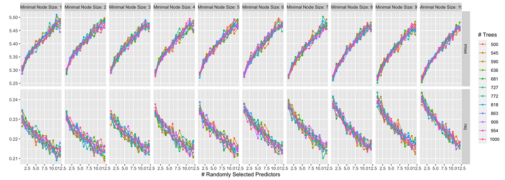

```r
rf_tree <- read_rds("tune_rf.rds")
autoplot(rf_tree)
```

I call the saved data here so we can check out the visuals they are pretty tight because there is so much to see. In this course we learned that the number of trees or node size is not as important as the number of randomly selected predictors in when looking at metrics. We tuned for all three of these values and from the looks of it our ideal values of rmse and r^2 are met when we have a lower amount of randomly selected predictors. The randomly selected predictors are for when we choose to make our tree model and it indicates what predictors and how many we would be splitting on as we go farther and farther down our tree mode. This data was run using the initial recipe which kept out the zone distances instead of using pca. The reason for this is because we ran it before the recipe changed and it took 12 hours just to run once. The values for rmse or r^2 will barely differ just based on how the other models did so we will keep it this way and avoid rerunning it.

```r
best_rf <- rf_tree %>%
  collect_metrics()%>%
  arrange(desc(mean))%>%
  head(1)
best_rf
```

```
## # A tibble: 1 × 9
##    mtry trees min_n .metric .estimator  mean     n std_err .config
##   <int> <int> <int> <chr>   <chr>      <dbl> <int>   <dbl> <chr>
## 1    11   818     1 rmse    standard    5.51    10   0.472 Preprocessor1_Model0…
```